# Project_3

Koohyar P, Anthony C, Victor T, & James N

2024-03-16

### Data Import

https://ballotpedia.org/Super_Tuesday_primaries,_2024

```r
url <- "https://ballotpedia.org/Super_Tuesday_primaries,_2024"
webpage <- read_html(url)
st_table <- html_nodes(webpage, '.portal-section')
table_names <- c("Alabama", "Alaska", "American Somoa", "Arkansas", "California", "Colorado", "Iowa", "Maine", "Massachusetts", "Minnesota", "North_Carolina", "Oklahoma", "Tennessee", "Texas", "Utah", "Vermont", "Virginia")
table_frames <- list()
for (i in seq_along(st_table)) {
  table_data <- html_table(st_table[[i]])
  table_name <- table_names[i]
  table_frames[[table_name]] <- table_data
}
# Sample Data Frame
table_frames$Alabama
```

```
## # A tibble: 15 × 5
##    X1    X2                      X3                                  X4    X5
##    <lgl> <chr>                   <chr>                               <chr> <chr>
##  1 NA    Candidate               %                                   Votes Pled…
##  2 NA    Joe Biden               89.5                                167,… 52
##  3 NA    Dean Phillips           4.5                                 8,391 0
##  4 NA    Other                   6.0                                 11,2… 0
##  5 NA    99% reporting Source    Total votes: 186,769 • Total pledg… <NA>  <NA>
##  6 NA    Candidate               %                                   Votes Pled…
##  7 NA    Donald Trump            83.2                                497,… 50
##  8 NA    Nikki Haley             13.0                                77,5… 0
##  9 NA    Ron DeSantis            1.4                                 8,426 0
## 10 NA    Vivek Ramaswamy         0.3                                 1,859 0
## 11 NA    Chris Christie          0.2                                 1,436 0
## 12 NA    David James Stuckenberg 0.1                                 748   0
## 13 NA    Ryan Binkley            0.1                                 508   0
## 14 NA    Other                   1.6                                 9,755 0
## 15 NA    99% reporting Source    Total votes: 598,035 • Total pledg… <NA>  <NA>
```

### Remove Extraneous Rows

```r
for (i in seq_along(table_frames)){
  # Filter the rows that contain the character string "% reporting"
  table_frames[[i]] <- table_frames[[i]][!grepl("% reporting", table_frames[[i]]$X2), ]
}
# Loop through each data frame removing the row that contains "Source" in column X2
for (i in seq_along(table_frames)){
  # Filter the rows that contain the character string "Source"
  table_frames[[i]] <- table_frames[[i]][!grepl("Source", table_frames[[i]]$X2), ]
}
# for (i in seq_along(table_frames)) {
#  print(table_frames[[i]])
#}
table_frames[[1]]
```

```
## # A tibble: 13 × 5
##    X1    X2                      X3    X4      X5
##    <lgl> <chr>                   <chr> <chr>   <chr>
##  1 NA    Candidate               %     Votes   Pledged delegates
##  2 NA    Joe Biden               89.5  167,165 52
##  3 NA    Dean Phillips           4.5   8,391   0
##  4 NA    Other                   6.0   11,213  0
##  5 NA    Candidate               %     Votes   Pledged delegates
##  6 NA    Donald Trump            83.2  497,739 50
##  7 NA    Nikki Haley             13.0  77,564  0
##  8 NA    Ron DeSantis            1.4   8,426   0
##  9 NA    Vivek Ramaswamy         0.3   1,859   0
## 10 NA    Chris Christie          0.2   1,436   0
## 11 NA    David James Stuckenberg 0.1   748     0
## 12 NA    Ryan Binkley            0.1   508     0
## 13 NA    Other                   1.6   9,755   0
```

### Adding Columns for State and Party affiliation

```
## # A tibble: 13 × 7
##    X1    X2                      X3    X4      X5                X6    X7
##    <lgl> <chr>                   <chr> <chr>   <chr>             <chr> <chr>
##  1 NA    Candidate               %     Votes   Pledged delegates state party
##  2 NA    Joe Biden               89.5  167,165 52                <NA>  <NA>
##  3 NA    Dean Phillips           4.5   8,391   0                 <NA>  <NA>
##  4 NA    Other                   6.0   11,213  0                 <NA>  <NA>
##  5 NA    Candidate               %     Votes   Pledged delegates state party
##  6 NA    Donald Trump            83.2  497,739 50                <NA>  <NA>
##  7 NA    Nikki Haley             13.0  77,564  0                 <NA>  <NA>
##  8 NA    Ron DeSantis            1.4   8,426   0                 <NA>  <NA>
##  9 NA    Vivek Ramaswamy         0.3   1,859   0                 <NA>  <NA>
## 10 NA    Chris Christie          0.2   1,436   0                 <NA>  <NA>
## 11 NA    David James Stuckenberg 0.1   748     0                 <NA>  <NA>
## 12 NA    Ryan Binkley            0.1   508     0                 <NA>  <NA>
## 13 NA    Other                   1.6   9,755   0                 <NA>  <NA>
```

### Extracting of Data Frames from List for Super Tuesday States

Selecting the proper columns, dropping the unnecessary ones. This also places “Democrat into the Party Column for ALL candidates, which will fixed in a later section to include Republican in the correct candidate. Pulls the individual state data frames out of the list to be worked on individually.

```
## # A tibble: 13 × 5
##    X2                      X3    X4      X6      X7
##    <chr>                   <chr> <chr>   <chr>   <chr>
##  1 Candidate               %     Votes   state   party
##  2 Joe Biden               89.5  167,165 alabama Democrat
##  3 Dean Phillips           4.5   8,391   alabama Democrat
##  4 Other                   6.0   11,213  alabama Democrat
##  5 Candidate               %     Votes   state   party
##  6 Donald Trump            83.2  497,739 alabama Democrat
##  7 Nikki Haley             13.0  77,564  alabama Democrat
##  8 Ron DeSantis            1.4   8,426   alabama Democrat
##  9 Vivek Ramaswamy         0.3   1,859   alabama Democrat
## 10 Chris Christie          0.2   1,436   alabama Democrat
## 11 David James Stuckenberg 0.1   748     alabama Democrat
## 12 Ryan Binkley            0.1   508     alabama Democrat
## 13 Other                   1.6   9,755   alabama Democrat
```

### Substituting Republican in the rows

This uses a filter that identifies the second occurrence in the column X2 that separates republican candidates from the democratic candidates, and then replaces “Democrat” with “Republican”. This is done for each individual data frame for the Super Tuesday states.

```
## # A tibble: 13 × 5
##    X2                      X3    X4      X6      X7
##    <chr>                   <chr> <chr>   <chr>   <chr>
##  1 Candidate               %     Votes   state   party
##  2 Joe Biden               89.5  167,165 alabama Democrat
##  3 Dean Phillips           4.5   8,391   alabama Democrat
##  4 Other                   6.0   11,213  alabama Democrat
##  5 Candidate               %     Votes   state   party
##  6 Donald Trump            83.2  497,739 alabama Republican
##  7 Nikki Haley             13.0  77,564  alabama Republican
##  8 Ron DeSantis            1.4   8,426   alabama Republican
##  9 Vivek Ramaswamy         0.3   1,859   alabama Republican
## 10 Chris Christie          0.2   1,436   alabama Republican
## 11 David James Stuckenberg 0.1   748     alabama Republican
## 12 Ryan Binkley            0.1   508     alabama Republican
## 13 Other                   1.6   9,755   alabama Republican
```

### Removing Candidate Rows

In this section, we remove the “candidate” row from each of the data frames and rename the column variable names from X to what they actually represent. We also address the accidental import of California candidates not running for the national office of president because they were placed in the same table on the website. Those candidates had their party affiliation and percent_vote values changes to NA.

| candidate | percent_vote | num_vote | state | party |
| --- | --- | --- | --- | --- |
| Joe Biden | 89.4 | 2,410,731 | california | Democrat |
| Marianne Williamson | 3.7 | 99,321 | california | Democrat |
| Dean Phillips | 2.8 | 75,313 | california | Democrat |
| Armando Perez-Serrato | 1.2 | 32,927 | california | Democrat |
| Gabriel Cornejo | 1.2 | 31,985 | california | Democrat |
| President Boddie | 0.7 | 19,651 | california | Democrat |
| Stephen Lyons Sr. | 0.6 | 16,946 | california | Democrat |
| Eban Cambridge | 0.3 | 9,106 | california | Democrat |
| Donald Trump | 78.8 | 1,505,027 | california | Republican |
| Nikki Haley | 17.8 | 339,502 | california | Republican |
| Ron DeSantis | 1.5 | 27,820 | california | Republican |
| Chris Christie | 0.9 | 16,476 | california | Republican |
| Vivek Ramaswamy | 0.4 | 8,171 | california | Republican |
| Rachel Hannah Swift | 0.2 | 3,393 | california | Republican |
| David James Stuckenberg | 0.2 | 3,086 | california | Republican |
| Ryan Binkley | 0.2 | 2,947 | california | Republican |
| Asa Hutchinson | 0.1 | 2,697 | california | Republican |
| Jill Stein | NA | 12,856 | california | NA |
| Charles Ballay | NA | 19,043 | california | NA |
| James P. Bradley | NA | 40,290 | california | NA |
| Claudia De La Cruz | NA | 5,273 | california | NA |
| Cornel West | NA | 4,433 | california | NA |
| Jasmine Sherman | NA | 1,491 | california | NA |

### Combining the Entire Data Frame

In this section we combine all the Super Tuesday state data frames into one tidy data frame containing five (5) variables and 205 rows. Once in, we will remove all the commas in the vote counts so we can use the data as numeric.

```r
# The Combine
super_tuesday_combine <- bind_rows(alabama, arkansas, california, colorado, maine, massachusets, minnesota, north_carolina, oklahoma, tennessee, texas, utah, vermont, virginia)

# Remove the commas
super_tuesday_combine$num_vote <- gsub(",", "", super_tuesday_combine$num_vote)
super_tuesday_combine
```

```
## # A tibble: 205 × 5
##    candidate               percent_vote num_vote state   party
##    <chr>                   <chr>        <chr>    <chr>   <chr>
##  1 Joe Biden               89.5         167165   alabama Democrat
##  2 Dean Phillips           4.5          8391     alabama Democrat
##  3 Other                   6.0          11213    alabama Democrat
##  4 Donald Trump            83.2         497739   alabama Republican
##  5 Nikki Haley             13.0         77564    alabama Republican
##  6 Ron DeSantis            1.4          8426     alabama Republican
##  7 Vivek Ramaswamy         0.3          1859     alabama Republican
##  8 Chris Christie          0.2          1436     alabama Republican
##  9 David James Stuckenberg 0.1          748      alabama Republican
## 10 Ryan Binkley            0.1          508      alabama Republican
## # ℹ 195 more rows
```

### Total Votes Cast by Party Affiliation and State

In this section we are going to identify the total number of votes cast by state, and then grouped by party affiliation.

```
##             state state_total state_party_total_d state_party_total_r
## 1         alabama      784804              186769              598035
## 2        arkansas      347379               81205              266174
## 3      california     4688485             2695980             1909119
## 4        colorado     1439162              573357              865805
## 5           maine      165400               63538              101862
## 6    massachusets     1188835              632869              555966
## 7       minnesota      581940              242291              339649
## 8  north_carolina     1770034              694323             1075711
## 9        oklahoma      403701               91561              312140
## 10     tennnessee      711514              133296              578218
## 11          texas     3294966              976680             2318286
## 12           utah      136207               61411               74796
## 13        vermont      135854               63609               72245
## 14       virginia     1044813              351141              693672
```

### Importing Next Dataset

In this section we are now going to import the state level data on regsitered voters and party affiliations. This comes from the websitehttps://worldpopulationreview.com/state-rankings/registered-voters-by-state. These figures are from October 2022, but should be accurate enough for our purposes of comparison with the voting electorate on Super Tuesday 2024. This import was much simpler due to the table structured format of the website, so the transformation and clean up are going to be much simpler. The initial import required us to move the first row to column names and then remove the fist row as an observation.

### Tidying and Transforming

In this section we are going to clean up the data frame a bit. We need to remove the commas and % in the values so we can do calculations later. We need to adjust the column names to be more workable, and we will need to mutate the population numbers to be comparable with the values in the other data frame (these are in thousands).

### Filtering the State Level Data to Only Super Tuesday States

```r
super_states <- state_final_2024$state
vote_2022af <- vote_2022[vote_2022$state %in% super_states, ]

combine_data_frame <- merge(state_final_2024, vote_2022af, by="state")

combine_data_frame
```

```
##         state state_total state_party_total_d state_party_total_r reg_voter_num
## 1     alabama      784804              186769              598035       2527000
## 2    arkansas      347379               81205              266174       1361000
## 3  california     4688485             2695980             1909119      18001000
## 4    colorado     1439162              573357              865805       2993000
## 5       maine      165400               63538              101862        832000
## 6   minnesota      581940              242291              339649       3436000
## 7    oklahoma      403701               91561              312140       1884000
## 8       texas     3294966              976680             2318286      13343000
## 9        utah      136207               61411               74796       1468000
## 10    vermont      135854               63609               72245        365000
## 11   virginia     1044813              351141              693672       4541000
##    perc_vote_pop
## 1          0.680
## 2          0.620
## 3          0.694
## 4          0.713
## 5          0.774
## 6          0.829
## 7          0.673
## 8          0.718
## 9          0.674
## 10         0.730
## 11         0.760
```

### Merging both Data sets

```r
## Merging Super_tuesday_combine with combine_data_frame
merge_combine<- merge(super_tuesday_combine,combine_data_frame, by="state",all.x = TRUE) %>%
  arrange((state), percent_vote)

merge_combine
```

```
##              state                  candidate percent_vote num_vote      party
## 1          alabama               Ryan Binkley          0.1      508 Republican
## 2          alabama    David James Stuckenberg          0.1      748 Republican
## 3          alabama             Chris Christie          0.2     1436 Republican
## 4          alabama            Vivek Ramaswamy          0.3     1859 Republican
## 5          alabama               Ron DeSantis          1.4     8426 Republican
## 6          alabama                      Other          1.6     9755 Republican
## 7          alabama                Nikki Haley         13.0    77564 Republican
## 8          alabama              Dean Phillips          4.5     8391   Democrat
## 9          alabama                      Other          6.0    11213   Democrat
## 10         alabama               Donald Trump         83.2   497739 Republican
## 11         alabama                  Joe Biden         89.5   167165   Democrat
## 12        arkansas    David James Stuckenberg          0.1      151 Republican
## 13        arkansas                Doug Burgum          0.1      155 Republican
## 14        arkansas               Ryan Binkley          0.1      183 Republican
```

[output cut: 603 more lines]

## Calculate Average

To better visualize the data I will provide a table that display state by their Average Total

```r
merge_combine_1 <- mutate(merge_combine, "Average_total"= rowMeans( select(merge_combine,"num_vote", "state_party_total_r", "state_party_total_r", "reg_voter_num") ) )

reactable(select(merge_combine_1, "state", "Average_total"))
```

| state | Average_total |
| --- | --- |
| alabama | 1041847.66666667 |
| alabama | 1041927.66666667 |
| alabama | 1042157 |
| alabama | 1042298 |
| alabama | 1044487 |
| alabama | 1044930 |
| alabama | 1067533 |
| alabama | 1044475.33333333 |
| alabama | 1045416 |
| alabama | 1207591.33333333 |

[output cut: 195 more lines]

### Filter Votes by Party

```r
# Members filter
Party_D <- merge_combine_1 %>% filter( party == "Democrat", na.omit(TRUE))
Party_R <- merge_combine_1 %>% filter(party == "Republican", na.omit(TRUE))
```

## Democratic vs Republican vote by state

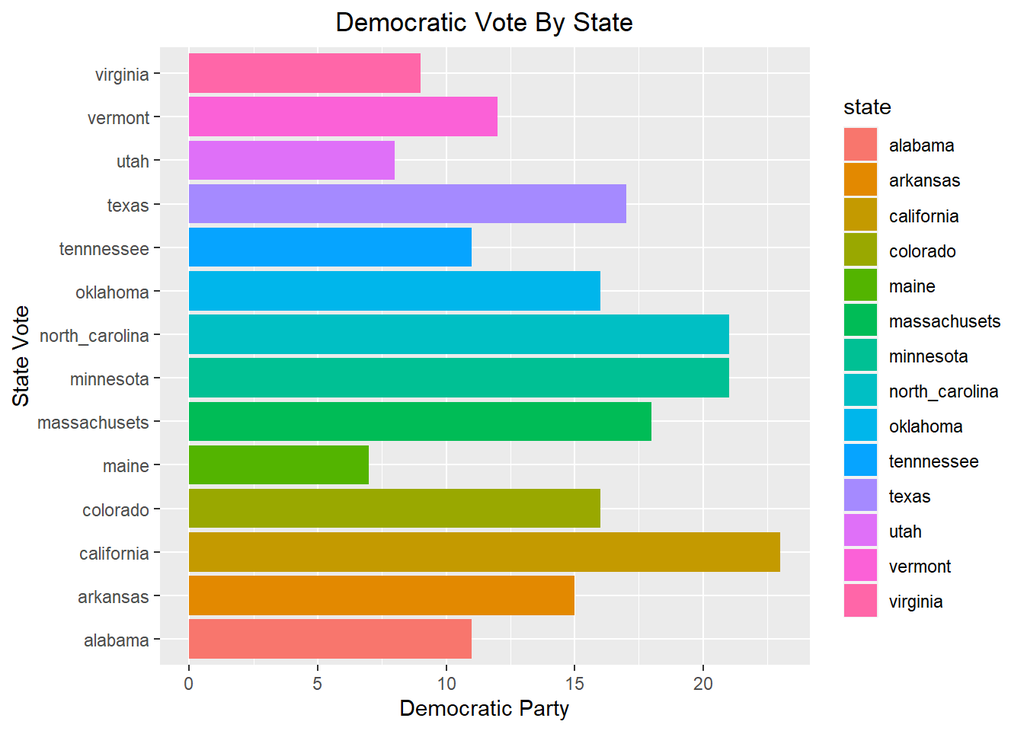

```r
## Democratic by state
D_plot <- ggplot(merge_combine_1, aes(y=merge_combine_1$state, fill = state)) + geom_bar(binwidth = 300) +
  ggtitle("Democratic Vote By State") +
  theme(plot.title = element_text(hjust=0.5)) +
  ylab("State Vote") +
  xlab("Democratic Party")

D_plot
```

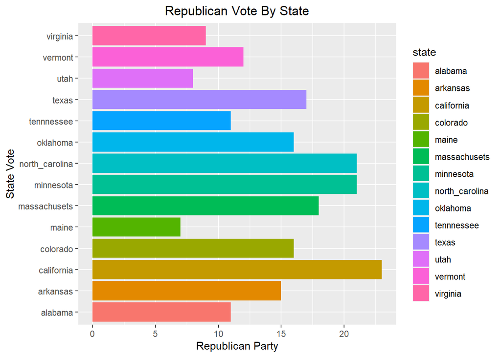

```r
## Republican by state
R_plot <- ggplot(merge_combine_1, aes(y=merge_combine_1$state, fill = state)) + geom_bar(binwidth = 300) +
  ggtitle("Republican Vote By State") +
  theme(plot.title = element_text(hjust=0.5)) +
  ylab("State Vote") +
  xlab("Republican Party")

R_plot
```

### Party Percentage by state

The plot below show the party percentage by state. We can see that the Republican party have the highest percent by state compare to the Democratic party.

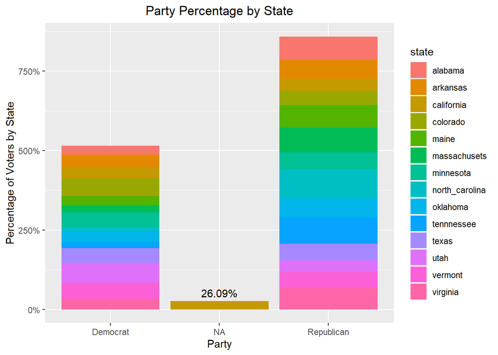

```r
myplot <- ggplot(merge_combine_1, aes(merge_combine_1$party, group = state)) +
          geom_text(aes( label = scales::percent(..prop..),
                   y= ..prop.. ), stat= "count", vjust = -.5) +
geom_bar(aes(y = ..prop.., fill = `state`, stat="count")) +
          scale_y_continuous(labels=scales::percent) +
          ggtitle("Party Percentage by State") +
         theme(plot.title = element_text(hjust=0.5)) +
          ylab("Percentage of Voters by State") +
          xlab("Party")

myplot
```

### Number of vote

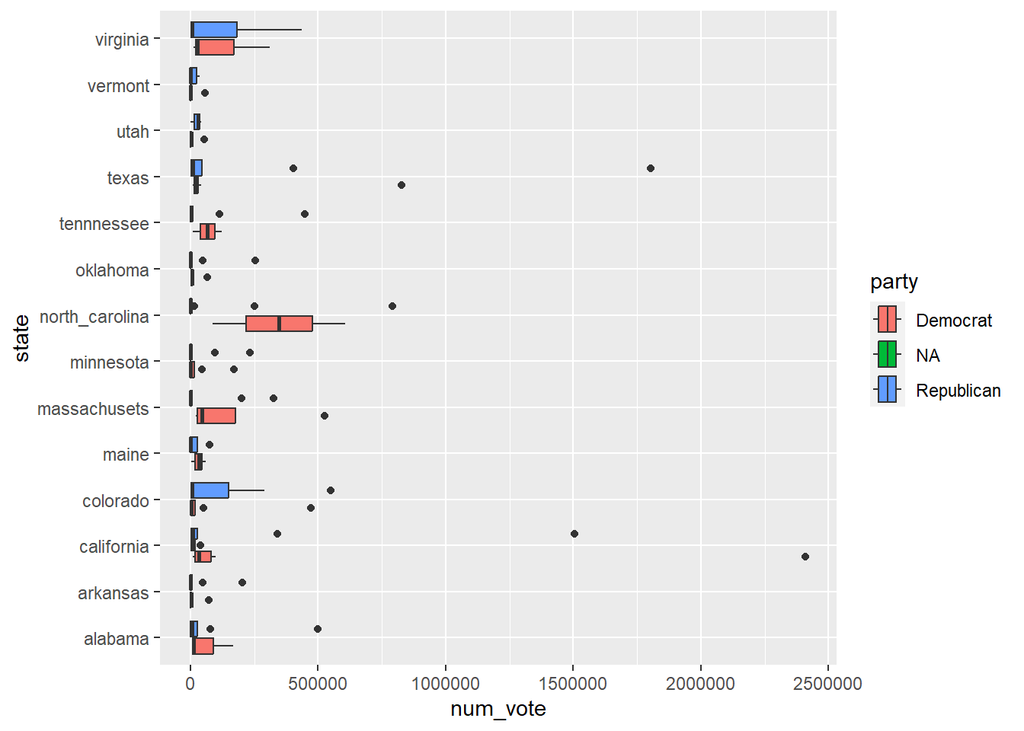

## Average Ttoal by Party

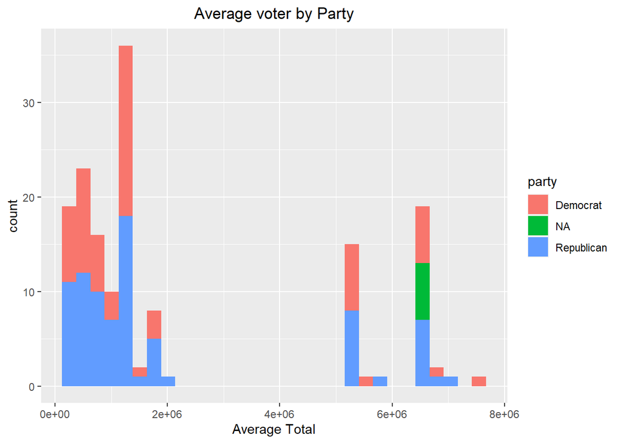